# Estudo de comportamento de pedidos por delta criação x janela de entrega

Fernanda Lasmar

2025-02-23

## AVD Estatística para Data Science 25.1

## Instalação RStudio

[figure not shown]

Programa instalado na máquina

[figure not shown]

Input do dataset no ambiente do RStudio

## Contexto do Estudo

### Base de Dados

Dados históricos de pedidos entregues e cancelados, incluindo variáveis operacionais relacionadas à jornada de compra e entrega.

### Objetivo

Identificar variáveis que interferem direta ou indiretamente no cancelamento de pedidos, especialmente por ruptura, para direcionar de forma mais eficiente as iniciativas dos stakeholders operacionais do iFood Shop.

## Estudo dos Dados

### Importação de Pacotes

```r
options(repos = c(CRAN = "https://cran.rstudio.com/"))

install.packages(c('tidyverse', 'dlookr', 'summarytools', 'ggplot2', 'readxl', 'knitr'))
```

[output not shown]

```
## instalando os pacotes de código-fonte 'summarytools', 'readxl'
```

```r
library(tidyverse)
library(dlookr)
library(summarytools)
```

```r
library(ggplot2)
library(readxl)
library(knitr)
```

### Importação do Dataset

```r
orders <- read.csv("C:/Users/fernanda.lasmar_ifoo/Desktop/pessoal/MBA_ds/EDS/avd-251/orders_shop.csv", header = TRUE)
```

### Validação da Importação

```r
kable(head(orders))
```

| uuid | data_criacao_pedido | data_referencia_completa | data_janela | bairro_buyer | cidade_buyer | customer_type | entregue | atraso | ruptura | cancelamento | cancelamento_ruptura | cancelamento_CNL | qtd_itens_solicitados | num_skus_solicitados | peso | diff_horas_criacao_inicio_janela |
| --- | --- | --- | --- | --- | --- | --- | --- | --- | --- | --- | --- | --- | --- | --- | --- | --- |
| 6996821c-bac1-41f5-a54f-ae32538a3d07 | 2024-11-07 14:30:27.210118 | 2024-11-08 14:37:43.119313 | 2024-11-08 13:00:00.000000 | VILA BRANDINA | CAMPINAS | NEW | 0 | 0 | 0 | 1 | 0 | 0 | 48 | 1 | 18.24 | 22 |
| 14b9c315-d3e1-430b-9da3-29c3c6117204 | 2024-12-21 15:03:15.433692 | 2024-12-23 16:13:38.852000 | 2024-12-23 10:00:00.000000 | INGA | NITEROI | NEW | 1 | 1 | 0 | 0 | 0 | 0 | 139 | 1 | 125.10 | 42 |
| 966c9489-7bf2-4815-ad98-e9181e796d3a | 2025-01-29 20:30:32.320178 | 2025-01-31 14:08:18.807000 | 2025-01-31 10:00:00.000000 | VILA NOVA | SAO PAULO | REACTIVATED | 1 | 1 | 0 | 0 | 0 | 0 | 22 | 4 | 38.00 | 37 |
| 5b447b44-ad13-451a-ba27-ef8d4b839f61 | 2025-01-30 19:03:02.244225 | 2025-02-03 16:19:09.544000 | 2025-02-03 16:00:00.000000 | BARRA DA TIJUCA | RIO DE JANEIRO | NEW | 1 | 0 | 0 | 0 | 0 | 0 | 23 | 2 | 34.50 | 92 |
| bb5969a7-dc02-4a2f-afe0-5b13def4e8a7 | 2024-12-10 06:18:44.895440 | 2024-12-11 16:32:57.065284 | 2024-12-11 16:00:00.000000 | SANTO ANTONIO | MOSSORO | NEW | 0 | 0 | 0 | 1 | 0 | 0 | 61 | 3 | 18.35 | 33 |
| 9553c1cd-f72b-4c22-b424-3b409c4bab86 | 2025-01-13 14:17:42.514491 | 2025-01-14 13:09:44.233000 | 2025-01-14 13:00:00.000000 | JARDIM PINHAL | GUARULHOS | ACTIVE | 1 | 0 | 0 | 0 | 0 | 0 | 90 | 1 | 99.00 | 22 |

### Diagnóstico dos Dados

```r
orders %>% dlookr::diagnose()
```

```
## # A tibble: 17 × 6
##    variables        types missing_count missing_percent unique_count unique_rate
##    <chr>            <chr>         <int>           <dbl>        <int>       <dbl>
##  1 uuid             char…             0         0              33595   0.933
##  2 data_criacao_pe… char…             0         0              33594   0.933
##  3 data_referencia… char…             0         0              33595   0.933
##  4 data_janela      char…             0         0                943   0.0262
##  5 bairro_buyer     char…             0         0               1600   0.0444
##  6 cidade_buyer     char…             0         0                105   0.00292
##  7 customer_type    char…             0         0                  3   0.0000833
##  8 entregue         inte…             0         0                  2   0.0000556
##  9 atraso           inte…             0         0                  2   0.0000556
## 10 ruptura          inte…             0         0                  2   0.0000556
## 11 cancelamento     inte…             0         0                  2   0.0000556
## 12 cancelamento_ru… inte…             0         0                  2   0.0000556
## 13 cancelamento_CNL inte…             0         0                  2   0.0000556
## 14 qtd_itens_solic… nume…             0         0                627   0.0174
## 15 num_skus_solici… inte…             0         0                 44   0.00122
## 16 peso             nume…           188         0.522           9366   0.260
## 17 diff_horas_cria… inte…             3         0.00833          121   0.00336
```

```r
orders$diff_horas_criacao_inicio_janela <- as.numeric(orders$diff_horas_criacao_inicio_janela)
```

## Análise Estatística

### Distribuição da Variável `diff_horas_criacao_inicio_janela`

```r
freq_raw <- summarytools::freq(orders$diff_horas_criacao_inicio_janela, style='rmarkdown', order='freq')
```

```
## setting plain.ascii to FALSE
```

```r
freq_df <- as.data.frame(freq_raw)
print(freq_df)
```

```
##        Freq      % Valid % Valid Cum.      % Total % Total Cum.
## 22     2569 7.136309e+00     7.136309 7.135715e+00     7.135715
## 23     2403 6.675185e+00    13.811495 6.674629e+00    13.810344
## 21     2196 6.100169e+00    19.911664 6.099661e+00    19.910005
## 20     2004 5.566821e+00    25.478486 5.566357e+00    25.476362
## 24     1977 5.491819e+00    30.970305 5.491362e+00    30.967724
## 19     1723 4.786244e+00    35.756549 4.785845e+00    35.753569
## 25     1548 4.300119e+00    40.056668 4.299761e+00    40.053330
## 26     1280 3.555654e+00    43.612323 3.555358e+00    43.608688
## 18     1244 3.455652e+00    47.067974 3.455364e+00    47.064052
## 17     1131 3.141754e+00    50.209728 3.141492e+00    50.205544
## 27     1041 2.891747e+00    53.101475 2.891506e+00    53.097050
## 16      895 2.486180e+00    55.587655 2.485973e+00    55.583023
## 39      799 2.219506e+00    57.807161 2.219321e+00    57.802344
## 28      725 2.013945e+00    59.821106 2.013777e+00    59.816121
```

[output cut: 108 more lines]

### Medidas Estatísticas

```r
media <- mean(orders$diff_horas_criacao_inicio_janela, na.rm = TRUE)
desvio_padrao <- sd(orders$diff_horas_criacao_inicio_janela, na.rm = TRUE)
quantil_25 <- as.numeric(quantile(orders$diff_horas_criacao_inicio_janela, probs = 0.25, na.rm = TRUE))
quantil_75 <- as.numeric(quantile(orders$diff_horas_criacao_inicio_janela, probs = 0.75, na.rm = TRUE))

print(media)
```

```
## [1] 36.79983
```

```r
print(desvio_padrao)
```

```
## [1] 22.09528
```

```r
print(quantil_25)
```

```
## [1] 21
```

```r
print(quantil_75)
```

```
## [1] 44
```

### Resumo Estatístico da Variável `diff_horas_criacao_inicio_janela`

```r
summarytools::descr(orders$diff_horas_criacao_inicio_janela)
```

```
## Descriptive Statistics
## orders$diff_horas_criacao_inicio_janela
## N: 36002
##
##                     diff_horas_criacao_inicio_janela
## ----------------- ----------------------------------
##              Mean                              36.80
##           Std.Dev                              22.10
##               Min                               1.00
##                Q1                              21.00
##            Median                              26.00
##                Q3                              44.00
##               Max                             232.00
##               MAD                              10.38
##               IQR                              23.00
##                CV                               0.60
##          Skewness                               1.39
##       SE.Skewness                               0.01
##          Kurtosis                               1.25
##           N.Valid                           35999.00
##                 N                           36002.00
##         Pct.Valid                              99.99
```

### Teste de normalidade das variáveis

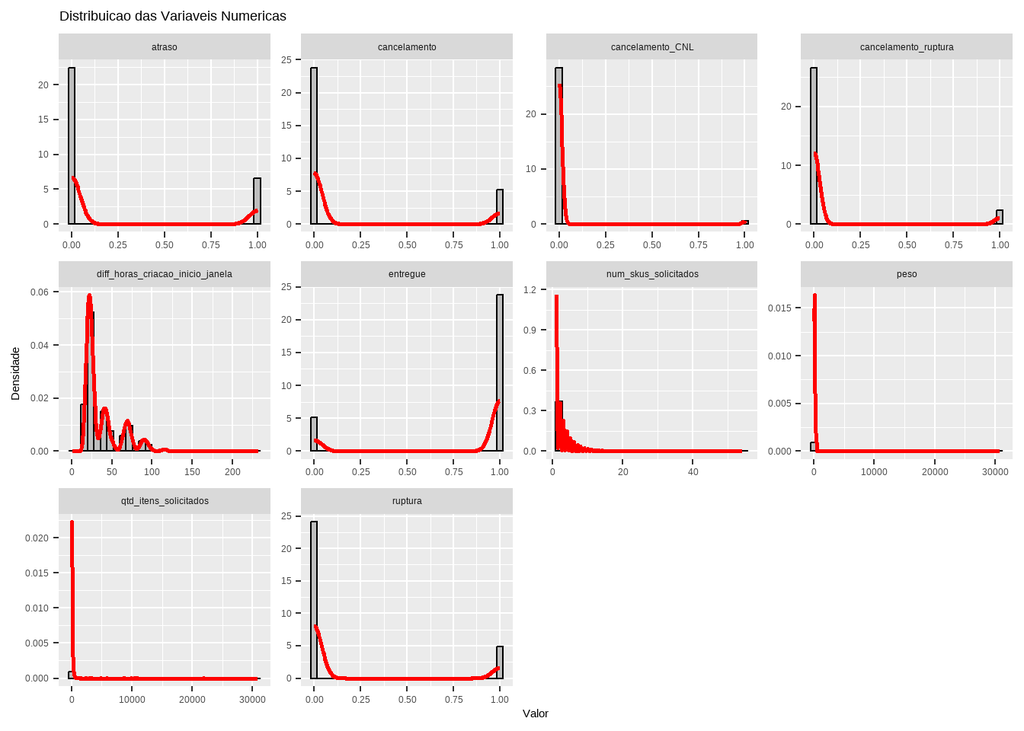

```r
numeric_vars <- orders %>% select_if(is.numeric)

numeric_vars %>%
  pivot_longer(everything(), names_to = "variavel", values_to = "valor") %>%
  drop_na() %>%  # Remove valores NA
  ggplot(aes(x = valor)) +
  geom_histogram(aes(y = after_stat(density)), fill = "grey", color = "black", bins = 30) +
  geom_density(color = "red", linewidth = 1) +
  facet_wrap(~variavel, scales = "free") +
  labs(title = "Distribuicao das Variaveis Numericas", x = "Valor", y = "Densidade")
```

Nenhuma variável segue uma distribuição normal. O que faz sentido considerando que é uma amostra de uma série temporal.

### Definição de Bins para o Histograma

Considerando que a coluna se trata do delta de horas entre a criação do pedido e o início da janela de entrega, faz sentido acompanhar por janela de 24h. No entanto, há algumas premissas do negócio a serem consideradas: 1. Durante a maior parte do dia de funcionamento da loja, os pedidos são criados para entrega no dia seguinte. 2. Somente é disponibilizada a compra para entrega com prazo maior que 2 dias em períodos específicos do ano, como feriados e eventos especiais.

```r
orders$diff_horas_bins <- cut(
  orders$diff_horas_criacao_inicio_janela,
  breaks = seq(0, max(orders$diff_horas_criacao_inicio_janela, na.rm = TRUE) + 24, by = 24),
  include.lowest = TRUE
)

table(orders$diff_horas_bins)
```

```
##
##    [0,24]   (24,48]   (48,72]   (72,96]  (96,120] (120,144] (144,168] (168,192]
##     16181     12078      4563      2760       394        19         3         0
## (192,216] (216,240]
##         0         1
```

```r
percent_3dias <- (16181 + 12078 + 4563) / 35999
percent_2dias <- (16181 + 12078) / 35999

print(percent_3dias)
```

```
## [1] 0.9117475
```

```r
print(percent_2dias)
```

```
## [1] 0.784994
```

Como observado, **91% dos pedidos** foram criados para entrega em até **3 dias**, sendo **78% deles para até 2 dias**. Dado esse contexto, faz mais sentido segregar os bins de forma mais granular até 3 dias (72h) e, a partir daí, utilizar janelas de 24h.

```r
orders$diff_horas_bins <- cut(
  orders$diff_horas_criacao_inicio_janela,
  breaks = c(seq(0, 72, by = 4), seq(96, max(orders$diff_horas_criacao_inicio_janela, na.rm = TRUE) + 24, by = 24)),
  include.lowest = TRUE
)

table(orders$diff_horas_bins)
```

```
##
##     [0,4]     (4,8]    (8,12]   (12,16]   (16,20]   (20,24]   (24,28]   (28,32]
##         4         0         0       930      6102      9145      4594      1017
##   (32,36]   (36,40]   (40,44]   (44,48]   (48,52]   (52,56]   (56,60]   (60,64]
##       739      2209      2356      1163       577       126       126       623
##   (64,68]   (68,72]   (72,96]  (96,120] (120,144] (144,168] (168,192] (192,216]
##      1477      1634      2760       394        19         3         0         0
## (216,240]
##         1
```

### Histograma de Variável `diff_horas_criacao_inicio_janela`

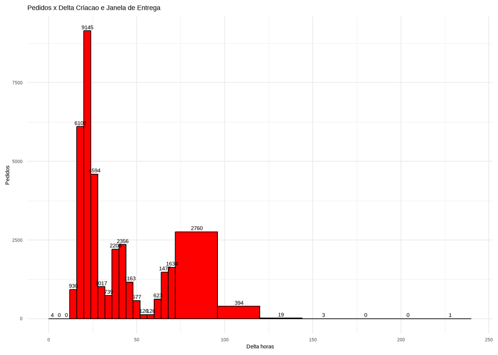

```r
ggplot(orders, aes(x = diff_horas_criacao_inicio_janela)) +
  geom_histogram(
    breaks = c(seq(0, 72, by = 4), seq(96, max(orders$diff_horas_criacao_inicio_janela, na.rm = TRUE) + 24, by = 24)),
    fill = "red", color = "black"
  ) +
  stat_bin(
    breaks = c(seq(0, 72, by = 4), seq(96, max(orders$diff_horas_criacao_inicio_janela, na.rm = TRUE) + 24, by = 24)),
    geom = "text",
    aes(label = after_stat(count)),
    vjust = -0.5, color = "black", size = 4
  ) +
  labs(title = "Pedidos x Delta Criacao e Janela de Entrega", x = "Delta horas", y = "Pedidos") +
  theme_minimal()
```

### Correlação entre as Variáveis

```r
correl <- cor(orders %>% select_if(is.numeric), use = "complete.obs")
print(correl)
```

```
##                                     entregue       atraso     ruptura
## entregue                          1.00000000  0.251589573  0.20966223
## atraso                            0.25158957  1.000000000  0.05116826
## ruptura                           0.20966223  0.051168261  1.00000000
## cancelamento                     -1.00000000 -0.251589573 -0.20966223
## cancelamento_ruptura             -0.63802473 -0.160520371 -0.13376969
## cancelamento_CNL                 -0.30313715 -0.076266146 -0.06355641
## qtd_itens_solicitados             0.02038984  0.071857456 -0.01786649
## num_skus_solicitados              0.10726640 -0.004602428  0.37841247
## peso                              0.01421986  0.067726069 -0.03504089
## diff_horas_criacao_inicio_janela -0.07893684 -0.001940623 -0.02205109
##                                  cancelamento cancelamento_ruptura
## entregue                          -1.00000000          -0.63802473
## atraso                            -0.25158957          -0.16052037
## ruptura                           -0.20966223          -0.13376969
## cancelamento                       1.00000000           0.63802473
## cancelamento_ruptura               0.63802473           1.00000000
## cancelamento_CNL                   0.30313715          -0.04202285
## qtd_itens_solicitados             -0.02038984          -0.01862922
## num_skus_solicitados              -0.10726640          -0.13083918
## peso                              -0.01421986          -0.01145448
## diff_horas_criacao_inicio_janela   0.07893684           0.05580854
##                                  cancelamento_CNL qtd_itens_solicitados
## entregue                             -0.303137151            0.02038984
## atraso                               -0.076266146            0.07185746
## ruptura                              -0.063556410           -0.01786649
## cancelamento                          0.303137151           -0.02038984
## cancelamento_ruptura                 -0.042022854           -0.01862922
## cancelamento_CNL                      1.000000000           -0.01106205
## qtd_itens_solicitados                -0.011062051            1.00000000
## num_skus_solicitados                  0.008100314           -0.01025532
## peso                                 -0.011782127            0.83196843
## diff_horas_criacao_inicio_janela      0.015321050            0.05197769
##                                  num_skus_solicitados        peso
## entregue                                  0.107266401  0.01421986
## atraso                                   -0.004602428  0.06772607
## ruptura                                   0.378412473 -0.03504089
## cancelamento                             -0.107266401 -0.01421986
## cancelamento_ruptura                     -0.130839180 -0.01145448
## cancelamento_CNL                          0.008100314 -0.01178213
## qtd_itens_solicitados                    -0.010255321  0.83196843
## num_skus_solicitados                      1.000000000 -0.03086606
## peso                                     -0.030866063  1.00000000
## diff_horas_criacao_inicio_janela         -0.061209574  0.04251920
##                                  diff_horas_criacao_inicio_janela
## entregue                                             -0.078936844
## atraso                                               -0.001940623
## ruptura                                              -0.022051089
## cancelamento                                          0.078936844
## cancelamento_ruptura                                  0.055808536
## cancelamento_CNL                                      0.015321050
## qtd_itens_solicitados                                 0.051977694
## num_skus_solicitados                                 -0.061209574
## peso                                                  0.042519204
## diff_horas_criacao_inicio_janela                      1.000000000
```

## ScatterPlots

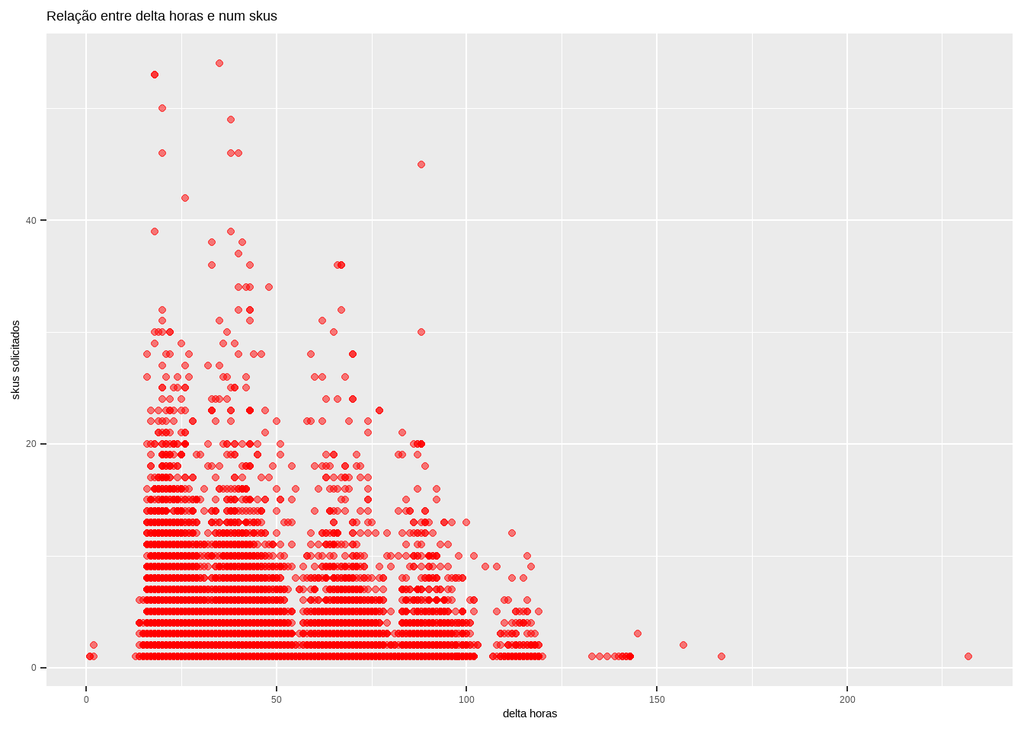

```r
ggplot(orders, aes(x = diff_horas_criacao_inicio_janela, y = num_skus_solicitados)) +
  geom_point(alpha = 0.5, color = "red") +
  labs(title = "Relação entre delta horas e num skus", x = "delta horas", y = "skus solicitados")
```

É possível observar que, apesar de maiores, os grandes pedidos não sofrem impacto na janela de entrega, sendo bem representantes em até 50h.

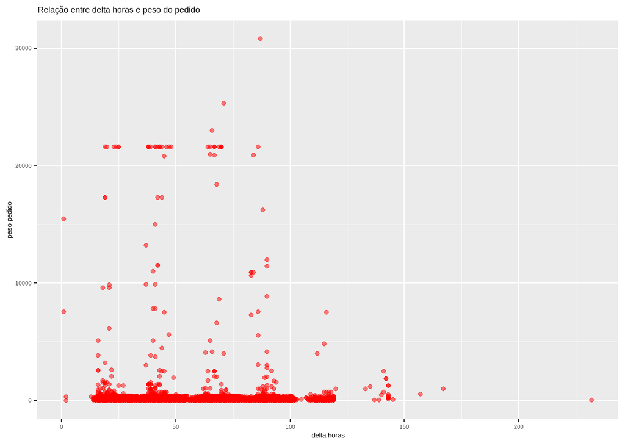

```r
ggplot(orders, aes(x = diff_horas_criacao_inicio_janela, y = peso)) +
  geom_point(alpha = 0.5, color = "red") +
  labs(title = "Relação entre delta horas e peso do pedido", x = "delta horas", y = "peso pedido")
```

O mesmo é visivel para pedidos pesados, apesar de serem pouco presentes como um todo. Nenhuma variável apresenta comportamento linear. Como próximos passos, pode ser interessante testar cenários de personalização da janela de entrega de acordo com variações de peso e tamanho do pedido